# Modelling part 3 -

# Machine Learning

## R-Ladies Freiburg

Wednesday 4th December

Elisa Schneider

### Random Forests

### Tree Based Methods

We use the **Hitters** data set to predict a baseball player's **Salary** based on

**Years**: the number of years that he has played in the major leagues and

**Hits**: the number of hits that he made in the previous year.

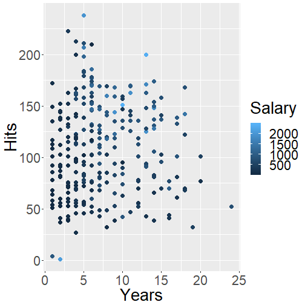

### Tree Based Methods

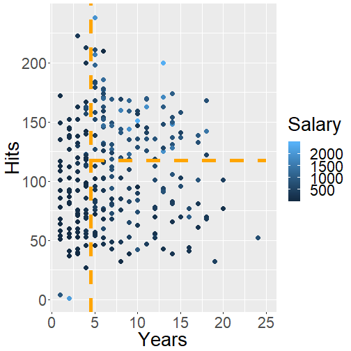

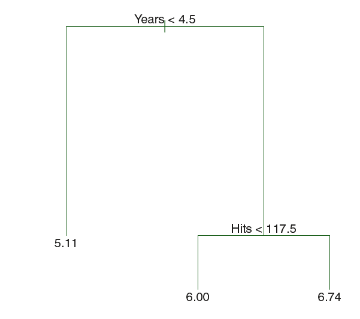

### Tree Based Method Vs. Linear Model

Which model is better?

It depends on the problem at hand.

- If the relationship between the features and the response is well approximated by a linear model, then an approach such as linear regression will likely work well and will outperform a method such as a regression tree.
- If instead there is a highly non-linear and complex relationship between the features and the response as indicated by model, then decision trees may outperform classical approaches.

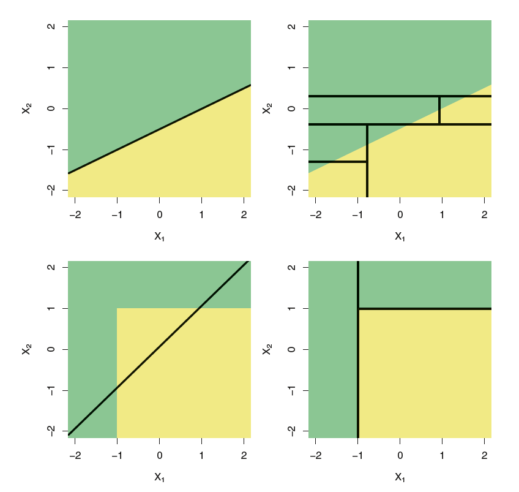

### High Variance of Trees

- The decision trees suffer from high variance: if we split the training data into two parts at random, and fit a decision tree to both halves, the results that we get could be quite different.
- A procedure with low variance will yield similar results; linear regression tends to have low variance.
- A natural way to reduce the variance and hence increase the prediction accuracy is to take many training sets from the population, build a separate prediction model using each training set, and average the resulting predictions.

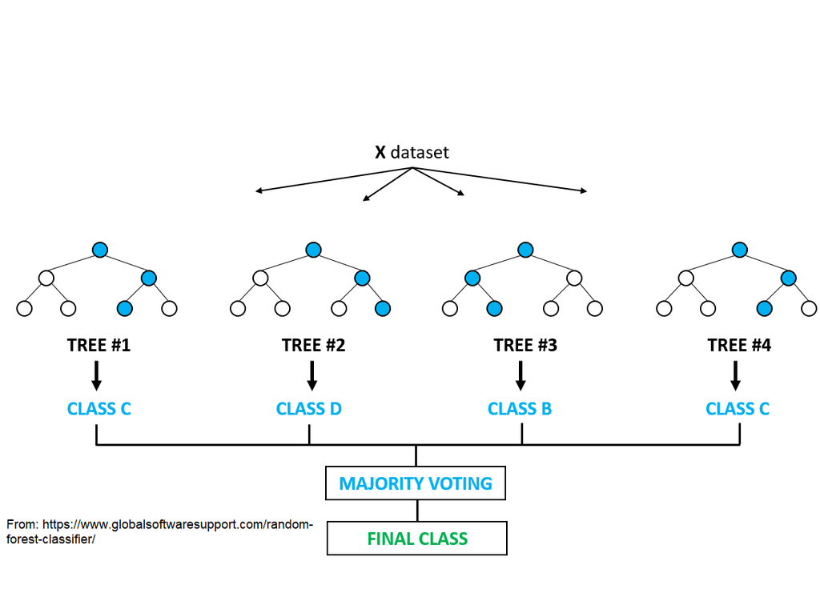

### Correlation of Trees

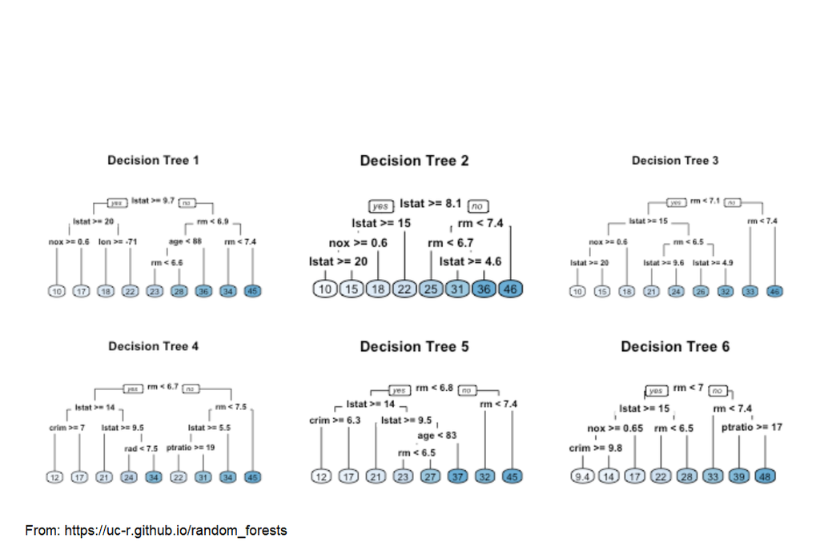

### Example

```r
library(readr)
library(randomForest)
library(MASS)
housing <- Boston

RFmodel <- randomForest(medv~., ntree=500, mtry=6, data=housing)

RFmodel
```

```
Call:
 randomForest(formula = medv ~ ., data = housing, ntree = 500,      mtry = 6)
               Type of random forest: regression
                     Number of trees: 500
No. of variables tried at each split: 6

          Mean of squared residuals: 9.899529
                    % Var explained: 88.27
```

### Example

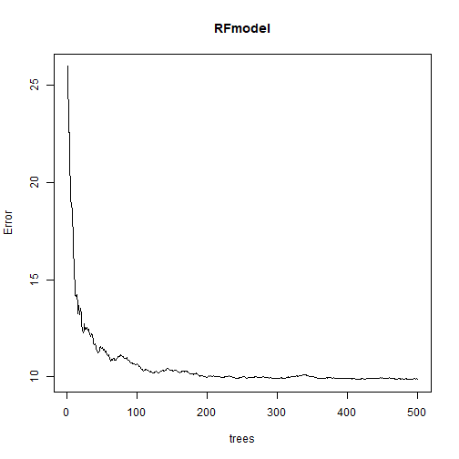

```r
plot(RFmodel)
```

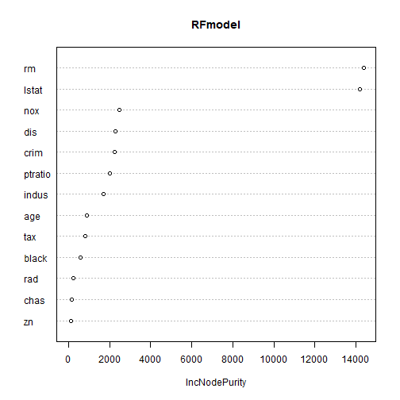

```r
varImpPlot(RFmodel)
```

### Artificial Neural Network

- ANN is an information processing model inspired by the biological neuron system.
- It is composed of a large number of interconnected processing elements: the neuron.
- ANN were designed to solve problems which are easy for humans and difficult for machines such as identifying patterns: distinguishing pictures of cats and dogs or recognizing numbers in pictures

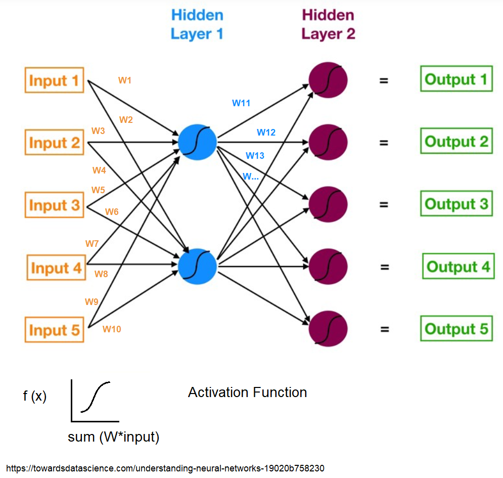

### ANN structure

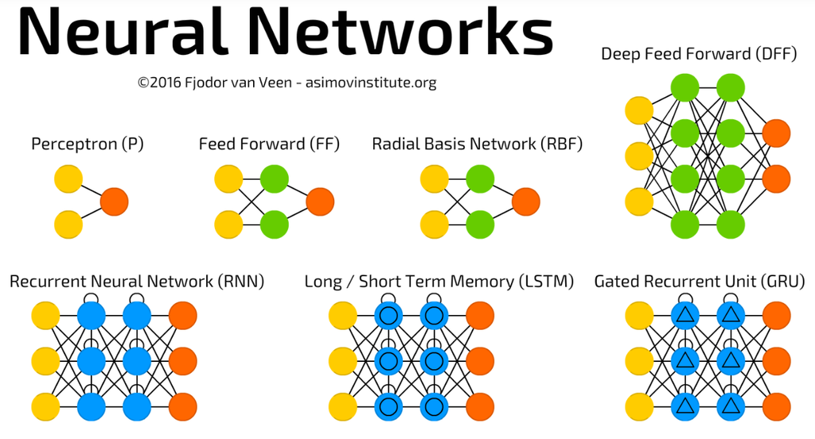

### Example

```r
index <- sample(1:nrow(housing),round(0.75*nrow(housing)))
train <- housing[index,]
test <- housing[-index,]
```

```r
maxs <- apply(housing, 2, max)
mins <- apply(housing, 2, min)
scaled <- as.data.frame(scale(housing, center = mins, scale = maxs - mins))
train_ <- scaled[index,]
test_ <- scaled[-index,]
```

### Example

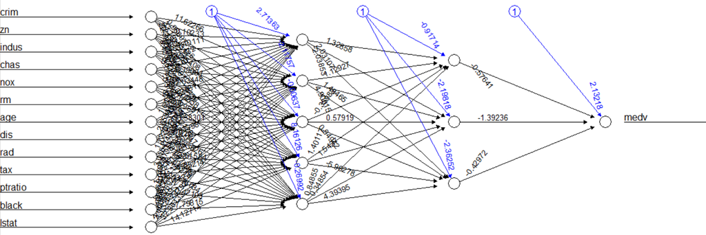

```r
library(neuralnet)
n <- names(train_)
f <- as.formula(paste("medv ~", paste(n[!n %in% "medv"], collapse = " + ")))
nn <- neuralnet(f, data=train_,hidden=c(5,3), linear.output=T)
plot (nn)
```

### Measuring performance

To test the model we can not use the same data used to fit the model. There are different strategies to test the model when we have only one data-set (this could be another hole Meet Up). One is what we did before, split the data set in two. An then calculate different measures to test the model:

- Regression

\[ RMSE = \sqrt\frac{\strut{\sum\limits_{i=1}^{n}{(\hat{y}_{i}-y_{i})^2}}}{n} \]

### Measuring performance

Classification (0,1)

```r
library(verification)
verification::roc.area(obs, pred)
```

Classification (More than two categories)

```r
table(obs, pred)

ggplot(longData, aes(x = Var2, y = Var1)) +
  geom_raster(aes(fill=value))

library(caret)
caret::confusion.matrix(obs, pred)
```

[More Info Here](https://www.datascienceblog.net/post/machine-learning/performance-measures-multi-class-problems/)